# DA5020 - Practicum 2

Jiaming Xu

Mar 28, 2022

## 1. Connecting to Mongodb and inserting data.

Outliers of ELAPSED_TIME and DISTANCE are retained.

Number of Observations is reduced from 1897503 (whole data), to 1261575 (daylight saving data),.

2. FL_DATE is converted to ISODate() in mongodb using update command.

```r
library(tidyverse)
library(mongolite)
library(rvest)

mongo_url = "mongodb+srv://jiamingxu:199410001@da5020-cluster.tsrxu.mongodb.net/da5020-cluster?retryWrites=true&w=majority"
con <- mongo(db = "airline_performance", collection = "flights_2019",
             url = mongo_url, verbose = TRUE)

# -------------------------
#   Codes below are only for the first compiling.
# -------------------------
#
# Drop previous loaded data.
#con$drop()
#
#df <- read_csv("2019_ONTIME_REPORTING_FSW.csv")
#df <- df %>%
#  mutate(FL_DATE = as.Date(FL_DATE, format=("%Y-%m-%d"))) %>%
#  filter( FL_DATE >= "2019-03-10" & FL_DATE <= "2019-11-03")
#
#con$insert(df)
#con$update('{}', update='[{"$set": { "FL_DATE": { "$toDate": "$FL_DATE"}}}]', multiple = TRUE)
```

## 2.

### a. Number of Flights.

```r
con$count('{}')
```

```
## [1] 1261575
```

### b. Mean and deviation of the elapsed time.

Mean and standard deviation of the elapsed time are calculated below. Data were retrived from Mongodb two times for mean and sd functions.

```r
con$aggregate( '[{ "$group": { "_id": true , "AverageElapsedTime": { "$avg": "$ELAPSED_TIME"}}}]')
```

```
##
 Found 1 records...
 Imported 1 records. Simplifying into dataframe...
```

|  | _id | AverageElapsedTime |
| --- | --- | --- |
| 1 | TRUE | 174.3721 |

```r
con$aggregate( '[{ "$group": { "_id": true , "SDofElapsedTime": { "$stdDevSamp": "$ELAPSED_TIME"}}}]')
```

```
##
 Found 1 records...
 Imported 1 records. Simplifying into dataframe...
```

|  | _id | SDofElapsedTime |
| --- | --- | --- |
| 1 | TRUE | 92.33789 |

## 3.

Preparing for CARRIER_CODE to Airline name converter function:

1. The rvest package is used for reading html then converting as a data frame.
2. Data frame rows contain NA are removed.
3. Regex is used for extracting only two-letter code IATA for the IATA column. (citation numbers and symbols are removed.)
4. Only the first name of company is returned if there are multiple IATA code matching.
5. Function IATA2NAME() can take a vector of IATA codes as input, return a rector containing company names.

Southwest airlines provide the most flights, followed by American Airlines, and United Airlines. SkyWest and Delta airlines posse 4th and 5th positions.

```r
airline_codes_url <-  "https://en.wikipedia.org/wiki/List_of_airline_codes"
airline_codes_html_raw <- read_html(airline_codes_url)

df <- airline_codes_html_raw %>%
    html_nodes(xpath = '//table') %>%
    html_table()

AIRLINE_CODE_DICT <- df[[1]] %>%
  select( c(IATA, Airline)) %>%
  filter( IATA != "") %>%
  mutate( IATA = str_extract(IATA, '\\w{2}')) %>%
  drop_na()

IATA2NAME <- function(x){
    sapply(x, function(y) {AIRLINE_CODE_DICT[AIRLINE_CODE_DICT[1] == y,2][1,]}) %>% as.character()
}

IATA2NAME("MQ")
```

```
## [1] "American Eagle Airlines"
```

```r
## Distinct carrier codes:
con$distinct("CARRIER_CODE")
```

```
##  [1] "AA" "AS" "B6" "DL" "EV" "F9" "G4" "HA" "MQ" "NK" "OO" "UA" "WN" "YV" "YX"
```

1. con$aggregate() is used for counting flights for each carrier.
2. add new column called CARRIER_NAME contains name of companies by using IATA2NAME function created previously.
3. Find top 10 companies who have the largest amount of flights.
4. Plot top 10 as a bar plot.

```r
flights_freq_top10 <- con$aggregate('[{ "$group": { "_id": "$CARRIER_CODE" , "count": {"$sum" : 1}}},
                              {"$sort": {"count": -1}},
                              {"$limit":10}]')
```

```
##
 Found 10 records...
 Imported 10 records. Simplifying into dataframe...
```

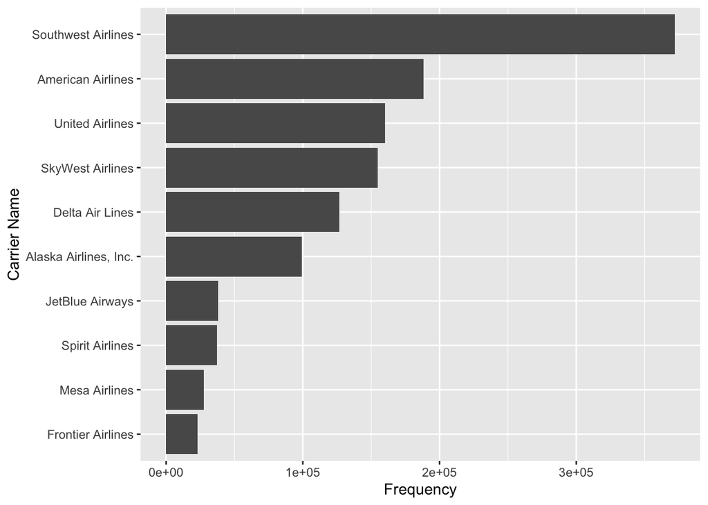

```r
flights_freq_top10 %>%
  as_tibble() %>%
  mutate( CARRIER_NAME = IATA2NAME(`_id`)) %>%
  ggplot() +
    geom_col( mapping = aes(x = reorder(CARRIER_NAME, count), y = count)) +
    coord_flip() +
    labs(y = "Frequency", x = "Carrier Name")
```

## 4. Total flight time

1. Find the top 5 carrier’s codes for retrieving data from Mongodb.
2. Retrieving AA, UA, OO, DL and WN flight data from Mongodb using $match.
3. Convert date to month using $trunc
4. Ggplot2 is used for plotting data as lines.

Delta airlines has largest frequency in July, and United airlines in Auguest.

```r
con$aggregate('[
              {"$group": { "_id": "$CARRIER_CODE" , "count": {"$sum" : 1}}},
              {"$sort": {"count": -1}},
              {"$limit":5}]')
```

```
##
 Found 5 records...
 Imported 5 records. Simplifying into dataframe...
```

|  | _id | count |
| --- | --- | --- |
| 1 | WN | 372110 |
| 2 | AA | 188110 |
| 3 | UA | 160243 |
| 4 | OO | 154828 |
| 5 | DL | 126499 |

```r
monthly_freq_top5 <- con$aggregate('[{ "$match": {"CARRIER_CODE":{ "$in" : ["AA", "UA", "OO", "DL", "WN"]}}},
              {"$project": {"elapsed_time":"$ELAPSED_TIME","CARRIER_CODE":"$CARRIER_CODE", "dateAttempted":1, "month":{ "$trunc" :{ "$month": "$FL_DATE"}}}},
              {"$group": {"_id": {"month":"$month", "CARRIER_CODE":"$CARRIER_CODE"}, "TotalFlightTime": {"$sum":"$elapsed_time"}}}]') %>%
  as_tibble() %>%
  unnest(`_id`)
```

```
##
 Found 45 records...
 Imported 45 records. Simplifying into dataframe...
```

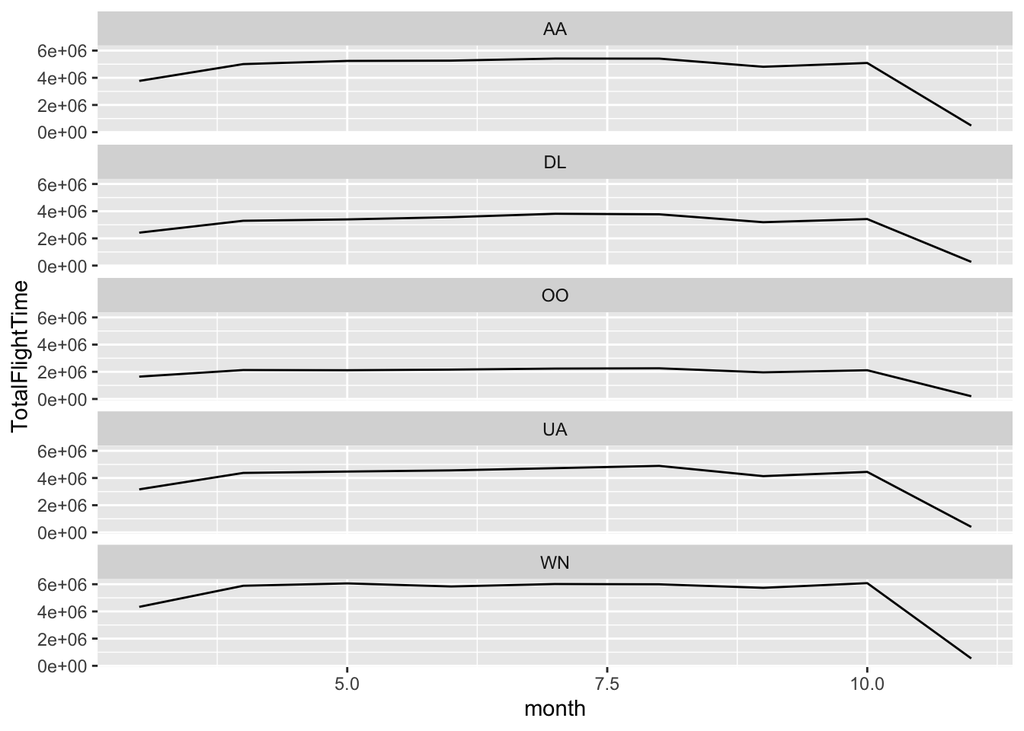

```r
monthly_freq_top5 %>%
  ggplot() +
  geom_line( mapping = aes(x = month, y = TotalFlightTime, group=CARRIER_CODE)) +
  facet_wrap( CARRIER_CODE ~ ., nrow = 5)
```

## 5. Busiest day in a week quaterly.

The busiest day in a week is defined by the longest total flights time each quarter.

1. Use $match function for screen out top 5 companies.
2. Use $project and $dayofweek functions to convert date to day of week. Also project other fields needs for next step.
3. group by dayofweek, carriercode, and quarter, calculate the total flight time

Five airlines follow the same daily trend in each quarter. Trends of different quarters are different.

```r
## dateQuarter was took from https://stackoverflow.com/questions/28291241/how-to-group-date-quarterly-wise

quarterly_busiest_top5 <-
  con$aggregate('[
                { "$match" : { "CARRIER_CODE" : { "$in": ["AA", "UA", "OO", "DL", "WN"]}}},
                { "$project": { "dayofweek": { "$dayOfWeek" : "$FL_DATE"},
                                "elapsed_time": "$ELAPSED_TIME",
                                "carrier_code":"$CARRIER_CODE",
                                "dateAttempted":1, "dateQuarter": { "$trunc": {"$add": [{"$divide": [{"$subtract": [{"$month": "$FL_DATE"},1]},3]},1]}}
                                }},
                { "$group": { "_id": {"dayofweek": "$dayofweek", "carrier_code":"$carrier_code", "dateQuarter":"$dateQuarter"},
                                      "totalFlightTime": {"$sum": "$elapsed_time"}}},
                { "$sort" : { "_id": 1}}]') %>%
  as_tibble() %>%
  unnest( cols = `_id`) ## Unnest tibble to two vectors.
```

```
##
 Found 140 records...
 Imported 140 records. Simplifying into dataframe...
```

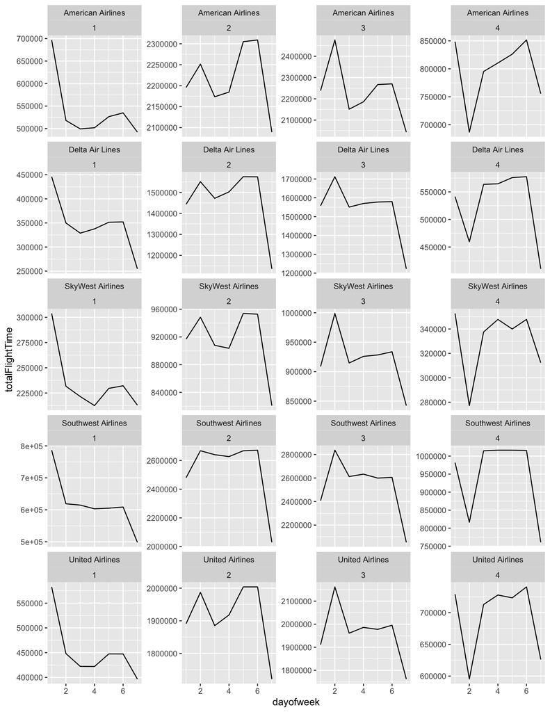

```r
quarterly_busiest_top5 %>%
  mutate(CARRIER_NAME = IATA2NAME(carrier_code)) %>%
  ggplot() +
  geom_line( mapping = aes( x = dayofweek, y = totalFlightTime,
                           group = CARRIER_NAME)) +
  facet_wrap( CARRIER_NAME ~ dateQuarter, nrow = 5, scales = 'free_y')
```

5. Display the values of busiest day each quarter for each Carrier for the numerical analysis.

```r
quarterly_busiest_top5 %>%
  group_by(dateQuarter,carrier_code) %>%
  filter( totalFlightTime == max(totalFlightTime))
```

| dayofweek | carrier_code | dateQuarter | totalFlightTime |
| --- | --- | --- | --- |
| 1 | AA | 1 | 696940 |
| 1 | DL | 1 | 445973 |
| 1 | OO | 1 | 303837 |
| 1 | OO | 4 | 352758 |
| 1 | UA | 1 | 582787 |
| 1 | WN | 1 | 786628 |
| 2 | AA | 3 | 2476729 |
| 2 | DL | 3 | 1712224 |
| 2 | OO | 3 | 998841 |
| 2 | UA | 3 | 2161641 |

[output cut: 10 more lines]

## 6. Flight lines, delays, and airports info of N109DU.

1. $ match for data of N109DU only
2. $project three fields for group and analyses
3. $group by ORIGIN+DEST, calculate the average arrival delay and departure delay.
4. calculate the operation of this flight.

```r
con$aggregate('[{ "$match": {"TAIL_NUM": "N109DU"}},
                { "$project": {"ORIDES": {"ORIGIN":"$ORIGIN", "DEST":"$DEST"},
                               "ARR_DELAY":"$ARR_DELAY",
                               "DEP_DELAY":"$DEP_DELAY"}},
                { "$group" : {"_id": "$ORIDES", "ave_arr_delay": { "$avg": "$ARR_DELAY"},
                                                "ave_dep_delay": { "$avg": "$DEP_DELAY"}}}]') %>%
  as_tibble() %>%
  unnest(`_id`)
```

```
##
 Found 10 records...
 Imported 10 records. Simplifying into dataframe...
```

| ORIGIN | DEST | ave_arr_delay | ave_dep_delay |
| --- | --- | --- | --- |
| SLC | SNA | 4.777778 | 7.555556 |
| SFO | SEA | 8.400000 | 9.700000 |
| SLC | SJC | 28.961538 | 26.692308 |
| SJC | SEA | 28.200000 | 28.000000 |
| SNA | SLC | 4.444444 | 0.000000 |
| SEA | SFO | 14.111111 | 14.148148 |
| SJC | SLC | 45.500000 | 48.071429 |
| SEA | SJC | 17.318182 | 18.272727 |
| SFO | SLC | 11.928571 | 11.357143 |
| SLC | SFO | 30.000000 | 31.352941 |

```r
# Which airline company operates this aircraft:
con$aggregate('[{ "$match": {"TAIL_NUM": "N109DU"}},
                {"$group": {"_id": "$CARRIER_CODE" }}]') %>%
    as_tibble() %>%
    pull(`_id`) %>%
    IATA2NAME()
```

```
##
 Found 1 records...
 Imported 1 records. Simplifying into dataframe...
```

```
## [1] "Delta Air Lines"
```

```r
con$aggregate('[{ "$match": {"TAIL_NUM": "N109DU"}},
                { "$project": {"DEST":"$DEST",
                               "ARR_DELAY":"$ARR_DELAY"}},
                { "$group" : {"_id": "$DEST", "ave_arr_delay": { "$avg": "$ARR_DELAY"},
                                                "count": {"$sum":1}}}]')
```

```
##
 Found 5 records...
 Imported 5 records. Simplifying into dataframe...
```

|  | _id | ave_arr_delay | count |
| --- | --- | --- | --- |
| 1 | SEA | 16.320000 | 50 |
| 2 | SFO | 20.250000 | 44 |
| 3 | SJC | 23.625000 | 48 |
| 4 | SNA | 4.777778 | 9 |
| 5 | SLC | 29.039216 | 51 |

```r
con$aggregate('[{ "$match": {"TAIL_NUM": "N109DU"}},
                { "$project": {"ORIGIN":"$ORIGIN",
                               "DEP_DELAY":"$DEP_DELAY"}},
                { "$group" : {"_id": "$ORIGIN", "ave_dep_delay": { "$avg": "$DEP_DELAY"},
                                                "count": {"$sum":1}}}]')
```

```
##
 Found 5 records...
 Imported 5 records. Simplifying into dataframe...
```

|  | _id | ave_dep_delay | count |
| --- | --- | --- | --- |
| 1 | SFO | 10.22727 | 44 |
| 2 | SEA | 16.00000 | 49 |
| 3 | SJC | 39.70833 | 48 |
| 4 | SLC | 24.90385 | 52 |
| 5 | SNA | 0.00000 | 9 |

## 7. Most common destination state - MA, CA and TX.

All most common destination state of three states are California.

Mongodb shell script:

db.flights_2019.aggregate([{ $match: { ORIGIN_ST: { $in: [“MA”, “CA”, “TX”] } } }, { $project: { DEST: “$DEST_ST”, ORIGIN_ST: “$ORIGIN_ST” } }, { $group: { _id: { DEST: “$DEST”, ORIGIN_ST: “$ORIGIN_ST” }, count: { $sum: 1 } } }, {$sort:{“count”:-1}}, {$group: {_id: “$_id.ORIGIN_ST”, “LARGEST”: {$first:“$_id.DEST”}, “count”: {$first:“$count”}}}])

This question is the most annoying one. At the beginning, I use $group twice, one for count and the other one for find the max in each group. However, other fields of the max observation couldn’t be extracted. I tried $push function to get DEST info, but it pushed all DEST in that group, which isn’t what I want. So I use sort first, then use $group and $first to extract them.

```r
con$aggregate('[ { "$match" :{ "ORIGIN_ST" :{ "$in": ["MA", "CA", "TX"]}}},
                 { "$project": {"DEST":"$DEST_ST",
                                "ORIGIN_ST":"$ORIGIN_ST"}},
              { "$group": {"_id": {"DEST":"$DEST", "ORIGIN_ST":"$ORIGIN_ST"}, "count": {"$sum": 1}}},
              { "$sort": {"count":-1}},
              { "$group": {"_id": "$_id.ORIGIN_ST", "DEST": {"$first": "$_id.DEST"}, "count":{"$first":"$count"}}}
              ]')
```

```
##
 Found 3 records...
 Imported 3 records. Simplifying into dataframe...
```

|  | _id | DEST | count |
| --- | --- | --- | --- |
| 1 | CA | CA | 165816 |
| 2 | TX | CA | 47041 |
| 3 | MA | CA | 8678 |

## 8. One more analysis - Correlation Between Departure Delay and Departure time.

From previous analyses we know that delay is related to airport location, and weather from life experience. Besides these two common reasons, does arrival time or departure time has any impact on delays? I will dig that out in this problem.

For convenience, two airports - SLC and BOS are analyzed.

1. Departure times are store as numbers on Mongodb, therefore I use $divide and $ceil function to convert them to hours only. NOTE: 1 means from 0 to 1, and so on.
2. Create average_dep_delay and delay_count information for plotting, grouped by origin and hour in a day.
3. Plot using ggplot, separate line and columns into two y axises. See legends and y-axis titles.

```
##
 Found 48 records...
 Imported 48 records. Simplifying into dataframe...
```

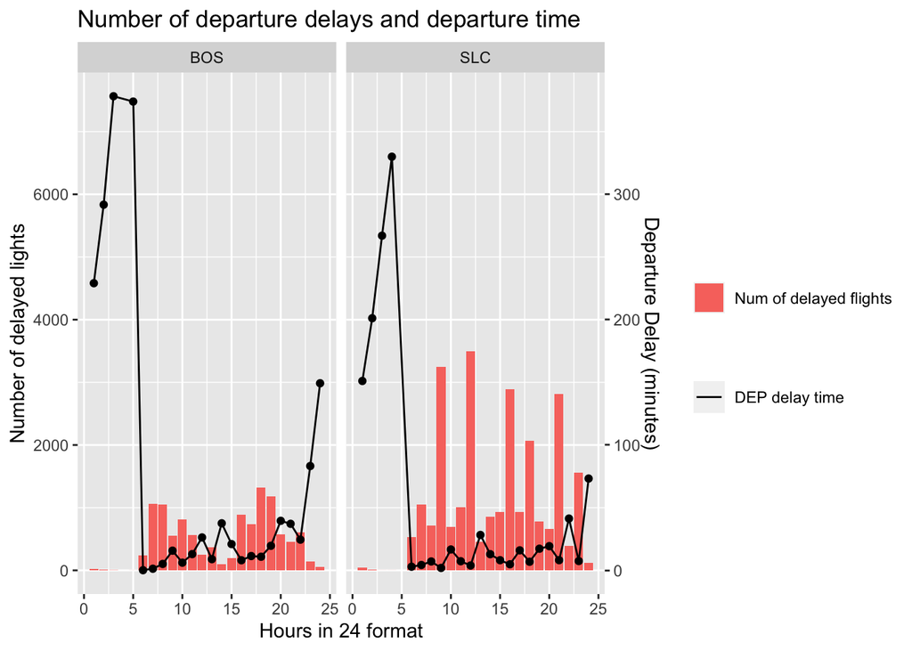

```r
con$aggregate('[{"$match": {"ORIGIN" :{ "$in": ["BOS", "SLC"]}}},
              {"$project": {"hour": {"$ceil":{"$divide": ["$DEP_TIME", 100]}}, "origin":"$ORIGIN", "dep_delay":"$DEP_DELAY"}},
              {"$group": {"_id": {"origin":"$origin", "hour":"$hour"}, "aveDepDelay":{"$avg":"$dep_delay"}, "delay_count":{"$sum":1}}}]') %>%
  as_tibble() %>%
  unnest(`_id`) %>%
  arrange(hour) %>%
  ggplot() +
  geom_bar( mapping = aes( x = hour, y = delay_count, fill = "Num of delayed flights"),
            stat = 'identity')+
  geom_line( mapping=aes( x = hour, y = aveDepDelay * 20, group = origin,
                           lty = 'DEP delay time'), color = "black") +
  geom_point( mapping=aes( x = hour, y = aveDepDelay * 20),color = "black") +
  scale_y_continuous(name = 'Number of delayed lights',
                     sec.axis = sec_axis(~./20, name = 'Departure Delay (minutes)')) +
  scale_linetype('') +
  labs(title = 'Number of departure delays and departure time',x = 'Hours in 24 format',
       fill = '') +
  facet_wrap( origin ~ .)
```

From the results we can see for Boston airport, departure delay time increase significantly after 21 o’clock. However, since the number of delayed flights after 21 o’clock is only a few, it’s not statistically significant. In general, number of delayed flights and delay time increases from noon to evening.